# Modelagem Preditiva Avançada

## Regressão Linear - Teoria

#### Datasets & PPT: https://github.com/rbarsotti/MBA/archive/master.zip

[output not shown]

Passo 1)

Primeiramente vamos importar os seguinter pacotes:

caret: Biblioteca para funcionalidade de ML mlbench: Biblioteca para Validação de Modelos ggplot2: Biblioteca para visualização de dados

### Importando Bibliotecas e Dados

```r
library(caret)
library(mlbench)
library(ggplot2)
```

Passo 2)

Agora vamos carregar o dataset, com cabeçalho (header=TRUE) e o separador de colunas sendo ','.

```r
df <- read.csv(file="/home/barsotti/Desktop/BostonRealEstate_Theory.csv", header=TRUE, sep=",")
```

Passo 3)

Agora vamos fazer uma rápida análise dos dados buscando identificar algumas relações visualmente e também verificar a qualidade dos dados.

### Análise dos Dados

```r
head(df)
```

| NBATH | CRIM | NROOMS | TAX | DISC | AGE | PRICE |
| --- | --- | --- | --- | --- | --- | --- |
| 3 | 0.81 | 5 | 70.19 | 111.03 | 70 | 111.03 |
| 1 | 0.68 | 3 | 75.10 | 123.09 | 17 | 118.94 |
| 1 | 0.69 | 2 | 78.89 | 223.98 | 3 | 167.12 |
| 3 | 0.89 | 5 | 96.97 | 68.86 | 97 | 68.86 |
| 1 | 0.73 | 3 | 39.79 | 161.36 | 15 | 145.42 |
| 1 | 0.56 | 2 | 40.68 | 137.97 | 17 | 127.69 |

```r
summary(df)
```

```
     NBATH            CRIM            NROOMS           TAX
 Min.   :1.000   Min.   :0.0000   Min.   :2.000   Min.   : 17.68
 1st Qu.:1.000   1st Qu.:0.4675   1st Qu.:3.000   1st Qu.: 46.51
 Median :3.000   Median :0.6600   Median :5.000   Median : 59.24
 Mean   :2.143   Mean   :0.6120   Mean   :3.998   Mean   : 60.13
 3rd Qu.:3.000   3rd Qu.:0.8000   3rd Qu.:5.000   3rd Qu.: 73.51
 Max.   :3.000   Max.   :0.9600   Max.   :5.000   Max.   :100.00
      DISC             AGE             PRICE
 Min.   : 50.52   Min.   :  1.00   Min.   : 49.61
 1st Qu.:124.08   1st Qu.: 13.00   1st Qu.:113.77
 Median :161.40   Median : 26.00   Median :137.82
 Mean   :166.65   Mean   : 34.55   Mean   :143.19
 3rd Qu.:202.98   3rd Qu.: 53.00   3rd Qu.:168.53
 Max.   :490.03   Max.   :100.00   Max.   :387.94
```

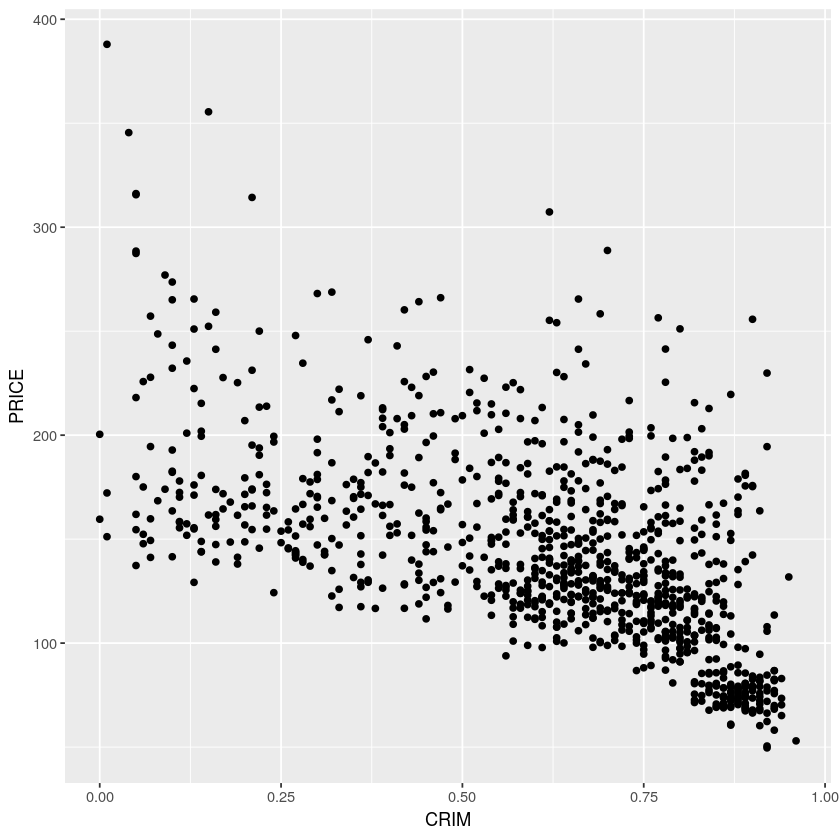

```r
ggplot(data = df, aes(x = CRIM, y = PRICE)) +
  geom_point()
```

### Particionando Dados em Treino e Teste

Passo 4)

Agora vamos particionar o dataset em treino/teste. Para isso definimos "p=0.7", isto é 70% da base será escolhida aleatóriamente para treino e 30% para teste do modelo.

Observe também que o "set.seed(x)" garante que ao replicarmos essa partição em outro computador por exemplo, os mesmos dados irão respectivamente prar treino e teste

```r
set.seed(280)
trainIndex <- createDataPartition(df$PRICE, p = .7, list = FALSE)
```

```r
dfTrain <- df[ trainIndex,]
dfTest  <- df[-trainIndex,]
```

### Treinando Modelo Univariado

Passo 5)

```r
set.seed(130)
model_uni <- train(PRICE~CRIM, data = dfTrain ,method = "lm")
```

### Validação Modelo

Passo 6)

Chamando o modelo obtemos informações como:

Número de amostras no treino

R<sup>2</sup>

etc

```r
model_uni
```

```
Linear Regression

700 samples
  1 predictor

No pre-processing
Resampling: Bootstrapped (25 reps)
Summary of sample sizes: 700, 700, 700, 700, 700, 700, ...
Resampling results:

  RMSE      Rsquared   MAE
  38.46412  0.3210979  29.61656

Tuning parameter 'intercept' was held constant at a value of TRUE
```

Passo 7)

Abaixo agora vamos obter os coeficientes do modelo, isto é:

$y = \alpha_1(X_1) + \alpha_2(X_2) + \alpha_3(X_3) ....$

$PRICE = \alpha_1(CRIM) + \alpha_2(AGE) +\alpha_3(DISC) ....$

```r
coef.icept <- coef(model_uni$finalModel)[1]
coef.slope <- coef(model_uni$finalModel)[2]
```

Passo 8)

Adicionando Gráfico para visualização do modelo linear no dataset.

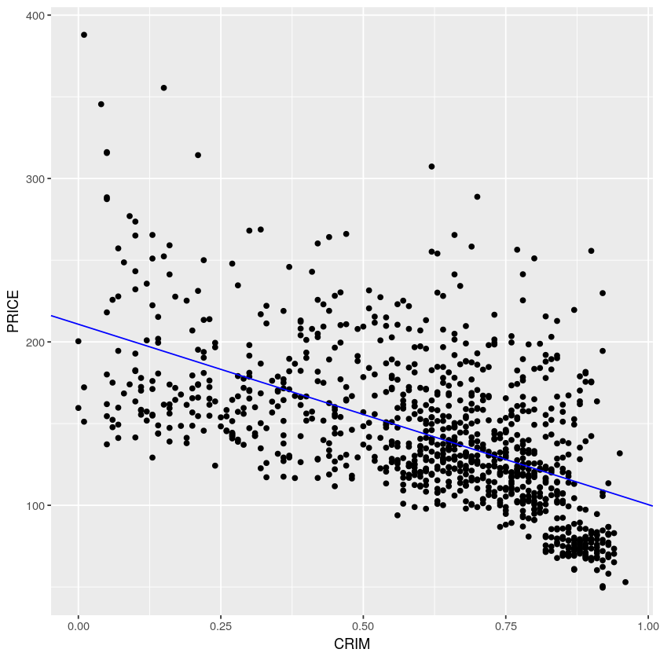

```r
ggplot(data = df, aes(x = CRIM, y = PRICE)) +
  geom_point() +
  geom_abline(slope = coef.slope, intercept = coef.icept, color = "blue")
```

### Treinando Modelo Multivariado

Passo 9)

Agora vamos treinar o modelo utilizando todas as variáveis disponíveis.

```r
set.seed(149)
model_mult <- train(PRICE~., data = dfTrain ,method = "lm")
```

```r
model_mult
```

```
Linear Regression

700 samples
  6 predictor

No pre-processing
Resampling: Bootstrapped (25 reps)
Summary of sample sizes: 700, 700, 700, 700, 700, 700, ...
Resampling results:

  RMSE      Rsquared   MAE
  24.90452  0.7276647  18.08579

Tuning parameter 'intercept' was held constant at a value of TRUE
```

Passo 10)

Utilizando a função VarImp do mlbench e plotando sua tabela vemos em oredem as features mais importantes do modelos

```
loess r-squared variable importance

       Overall
DISC   0.68328
CRIM   0.31335
TAX    0.11800
AGE    0.04184
NBATH  0.01544
NROOMS 0.01515
```

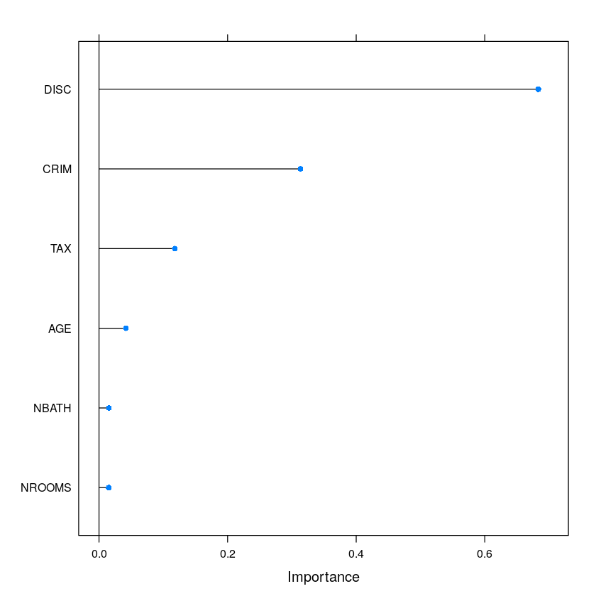

```r
imp <- varImp(model_mult ,useModel=FALSE, scale=FALSE)
imp
plot(imp)
```

Passo 11)

Agora com o modelo treinado podemos fazer o "scoring" nos dados que haviam sindo separados para teste e quaisquer outros que o modelo ainda não tenha visto.

```r
y_Model <- predict(model_mult, dfTest)
dfTest$Model <- y_Model
head(dfTest)
```

|  | NBATH | CRIM | NROOMS | TAX | DISC | AGE | PRICE | Model |
| --- | --- | --- | --- | --- | --- | --- | --- | --- |
| 4 | 3 | 0.89 | 5 | 96.97 | 68.86 | 97 | 68.86 | 87.10855 |
| 12 | 1 | 0.39 | 3 | 49.16 | 180.49 | 14 | 161.39 | 154.71240 |
| 14 | 3 | 0.79 | 5 | 71.91 | 117.20 | 72 | 117.20 | 117.35900 |
| 17 | 3 | 0.82 | 5 | 93.92 | 113.82 | 94 | 113.82 | 116.84639 |
| 20 | 2 | 0.33 | 4 | 31.33 | 233.26 | 20 | 222.08 | 195.23554 |
| 23 | 3 | 0.88 | 5 | 77.65 | 70.99 | 78 | 70.99 | 86.76292 |